# Statistical test using R

2018-09-27

[예제 및 데이터 출처] 켈러의 경영경제통계학, Geraled Keller, 10th edition 에서 발췌하였음

# 1 모평균에 대한 검정 : t 검정

- t.test() 함수는 일표본(one sample) 과 이표본(two sample) 의 모평균에 대한 t-검정을 수행한다.
  - t.test() 함수는 두 집단에 대해 서로 다른 분산(unequal variance)을 가정하며, Welsh 의 자유도를 사용하여 t-검정을 수행한다.
  - var.equal=TRUE 옵션은 모집단에 대해 등분산을 가정하고, 등분산에 대한 추정치를 사용하여 t-검정을 수행한다.
  - alternative=“two.sided(default)”, “less”, “greater” 옵션을 제공한다.

## 1.1 One sample t-test

### 1.1.1 [예제 1] 신문용지 재활용공장

현재 재활용 자원으로부터 제조되는 대부분의 생산물들은 천연자원으로부터 제조되는 생산물보다 훨씬 더 비싸다. 예를들면, 재활용 유리로부터 유리병을 생산하는 비용은 천연자원인 규사(slica sand), 소다회(soda ash), 석회석(limestone)으로부터 유리병을 생상하는 비용보다 약 3배 비싸다. 재활용 캔으로부터 알루미늄 캔을 제조하는 비용은 보크사이트(bauxite) 로부터 알루미늄 캔을 제조하는 비용보다 더 비싸다.  
하나의 예외가 신문용지이다. 신문용지는 재활용할 때 이윤을 발생시킬 수 있다. 그러나 신문용지 재활용에 있어서 대부분의 비용은 가구로부터 신문용지를 수거하는데 소요된다. 최근에 한 신문용지 재활용회사의 한 재무분석가는 각 가구로부터 수집되는 주간 평균 신문용지량이 2.0 파운드를 초과하면 이윤이 발생할 것이라고 계산하였다. 신문용지 재활용 공장의 설립 타당성을 결정하기 위한 연구에서 한 대형 커뮤니티로부터 148가구로 구성된 임의표본이 추출되었고, 각 가구가 재활용을 위해 버리는 주간 신문용지량이 기록되었다. 이러한 추세라면 신문용지 재활용공장은 이윤을 발생시킬 수 있을 것인가?

- 문제의 목적은 모집단에 속한 각 가구에 의해 버려지는 주간 신문용지량으로 구성되어 있는 모집단의 특성을 파악하는 것이다.
- 모수인 모평균이 2.0 파운드보다 큰지를 결정할 필요가 있기 때문에 대립가설과 귀무가설은 다음과 같이 결정된다.

$H_1: \mu > 2.0$ $H_0: \mu = 2.0$

```r
newspaper <- read.csv("data/newspaper.csv")
newspaper <- newspaper[, 1] # 첫번째 컬럼만 선택

# 유의수준 5%
t.test(newspaper, mu = 2.0, alternative = "greater", paired=F, var.equal=F, conf.level=0.95) # one-tail
```

```
##
##  One Sample t-test
##
## data:  newspaper
## t = 2.2369, df = 147, p-value = 0.0134
## alternative hypothesis: true mean is greater than 2
## 95 percent confidence interval:
##  2.046905      Inf
## sample estimates:
## mean of x
##  2.180405
```

```r
qt(0.95, df=147) # 유의수준 5% 일때의 기각역 1.655
```

```
## [1] 1.655285
```

```r
# 유의수준 1%
t.test(newspaper, mu = 2.0, alternative = "greater", paired=F, var.equal=F, conf.level=0.99) # one-tail
```

```
##
##  One Sample t-test
##
## data:  newspaper
## t = 2.2369, df = 147, p-value = 0.0134
## alternative hypothesis: true mean is greater than 2
## 99 percent confidence interval:
##  1.990716      Inf
## sample estimates:
## mean of x
##  2.180405
```

```r
qt(0.99, df=147) # 유의수준 1% 일때의 기각역 2.351
```

```
## [1] 2.351983
```

- 유의수준 5% 일때는,
1. 검정통계량 값 t = 2.2369 는 기각역 = 1.655 내에 존재하고
2. **p value 0.0134 는 0.05보다 작으므로**

   귀무가설을 기각하고 대립가설을 채택할 충분한 근거가 존재.
- 유의수준 1% 일때는,
1. 검정통계량 값 t = 2.2369 는 기각역 = 2.351 내에 존재하지 않고,
2. **p value 0.0134 는 0.01보다 크므로**

   귀무가설을 기각하고 대립가설을 채택할 충분한 근거가 존재하지 않음. 각 가구로부터 버려지는 주간 평균 신문용지량이 2.0 보다 추론할 수 있는 충분한 근거가 존재하지 않으므로, 신문용지 재활용 공장이 이윤을 발생시킬 것이라고 결론 내릴 수 없다.

*의사결정자가 제1종 오류(모평균이 2.0보다 크지 않은데 2.0보다 크다고 결론을 내리는 오류)의 비용이 매우 크다고 생각한다면 유의수준을 1%로 설정할 것*

```r
paper_t <- t.test(newspaper, mu = 2.0, alternative = "greater", paired=F, var.equal=F, conf.level=0.99)
round(paper_t$statistic, 4)  # t value 만 추출,
```

```
##      t
## 2.2369
```

## 1.2 Two independent samples t-test (독립표본 t 검정)

독립된 두집단의 t-검정을 할 때는 두가지 가정이 만족되는지 먼저 확인해봐야 한다.

1. 정규성 가정 : 두 집단의 분포가 정규분포를 따른다고 할 수 있는지
2. 등분산성 가정 : 두 집단의 분산이 같다고 할 수 있는지

### 1.2.1 [예제 2] 뮤추얼 펀드의 수익률 비교

투자자들은 브로커를 통해 뮤추얼 펀드를 구매하는 것보다 직접 뮤추얼 펀드를 구매하는 것에 의해 더 좋은 투자성과를 얻을 수 있는가? 이와 같은 질문에 답변하기 위해 일단의 연구자들은 직접 구매될 수 있는 뮤추얼 펀드들과 브로커를 통해 구매될 수 있는 뮤추얼 펀드들로부터 임의로 연간수익률을 표본으로 추출하고, 모든 관련 수수료를 공제한 후의 투자수익률을 의미하는 연간순수익률을 기록하였다.  
직접 구매한 뮤추얼 펀드의 연간 순수익률이 브로커를 통해 구매한 뮤추얼펀드의 연간수익률보다 더 높다고 5% 유의수준에서 결론내릴 수 있는가?

```r
roi <- read.csv("data/roi.csv")
str(roi)  # 50 obs. of  2 variables
```

```
## 'data.frame':    50 obs. of  2 variables:
##  $ Direct: num  9.33 6.94 16.17 16.97 5.94 ...
##  $ Broker: num  3.24 -6.76 12.8 11.1 2.73 ...
```

- 검정되어야 하는 모수 : 두 모형균의 차이 $\mu_1 - \mu_2$
- 검정되어야 하는 가설 : 직접 구매한 뮤추얼 펀드의 평균 연간순수익률 ($\mu_1$) 이 브로커를 통해 구매한 뮤추얼 펀드의 평균 연간순수익률 ($\mu_2$) 보다 더 크다는 것.
- 대립가설 $H_1: (\mu_1 - \mu_2) > 0$
- 귀무가설 $H_0: (\mu_1 - \mu_2) = 0$

### 1.2.2 정규성 검사

- 정규성 검정은 히스토그램과 qqplot(), qqline() 을 통해 분포가 얼마가 정규분포에 근사한지 확인할 수 있다.

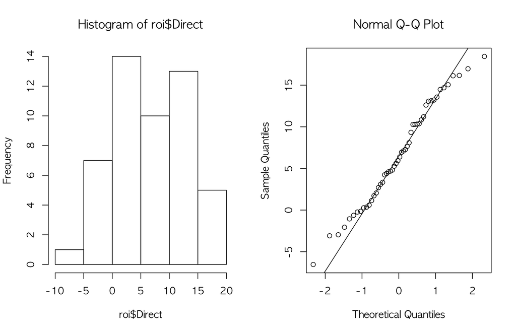

```r
par(mfrow = c(1,2))
hist(roi$Direct)  # 종모양에 근사
qqnorm(roi$Direct)
qqline(roi$Direct)
```

### 1.2.3 등분산 F 검정

- 먼저 $\mu_1 - \mu_2$ 에 대한 t-검정 (var.equal = FALSE|TRUE) 중 어느 것을 선택하여야 하는지를 결정하기 위해 $\sigma_1^2/\sigma_2^2$ 에 대한 F 검정이 수행된다.

$H_0: \sigma_1^2/\sigma_2^2 = 1$ $H_1: \sigma_1^2/\sigma_2^2 != 1$

```r
# Do x and y have the same variance?
var.test(roi$Direct, roi$Broker)
```

```
##
##  F test to compare two variances
##
## data:  roi$Direct and roi$Broker
## F = 0.86499, num df = 49, denom df = 49, p-value = 0.6137
## alternative hypothesis: true ratio of variances is not equal to 1
## 95 percent confidence interval:
##  0.490863 1.524281
## sample estimates:
## ratio of variances
##          0.8649931
```

- var.test() 함수의 출력결과는 F비율값
- 검정통계량 F = 0.8650, p-value = 0.6137
- 두 모분산이 다르다고 추론할 수 있는 충분한 증거가 존재하지 않는다. 따라서 $\mu_1 - \mu_2$ 에 대한 등분산 t 검정((var.equal = TRUE) 이 적용되어야 한다.

```r
t.test(roi$Direct, roi$Broker, alternative = "greater", paired = FALSE, var.equal = TRUE)  # 독립표본, 등분산, 단측검정
```

```
##
##  Two Sample t-test
##
## data:  roi$Direct and roi$Broker
## t = 2.2872, df = 98, p-value = 0.01217
## alternative hypothesis: true difference in means is greater than 0
## 95 percent confidence interval:
##  0.7967156       Inf
## sample estimates:
## mean of x mean of y
##    6.6312    3.7232
```

- 검정통계량 값은 t = 2.2872, 단측 p-value = 0.01217
- 검정의 p 값이 유의수준 5% 보다 작고 검정통계량이 기각역에 속한다. 따라서 귀무가설을 기각하고 대립가설을 채택한다.
- 평균적으로 직접 구매한 뮤추얼 펀드의 연간 순수익률은 브로커를 통해 구매한 뮤추얼 펀드의 연간순수익률보다 크다고 추론할 수 있는 충분한 근거가 존재한다.

## 1.3 Matched pairs samples t-test(짝진표본)

- 짝진표본(대응표본) t검정은 어떠한 처리를 했을 때 표본 집단의 전후 차이가 있는지 여부를 검정하는 방법

### 1.3.1 [예제 3] 고섬유질 아침 시리얼의 다이어트 효과

```r
sereal <- read.csv("data/sereal.csv")
str(sereal)
```

```
## 'data.frame':    107 obs. of  2 variables:
##  $ before: int  705 819 706 509 613 582 601 608 787 573 ...
##  $ after : int  568 498 589 681 540 646 636 739 539 596 ...
```

```r
sereal <- na.omit(sereal)  # NA 값이 존재하는 관측치 삭제
```

### 1.3.2 정규성 검사

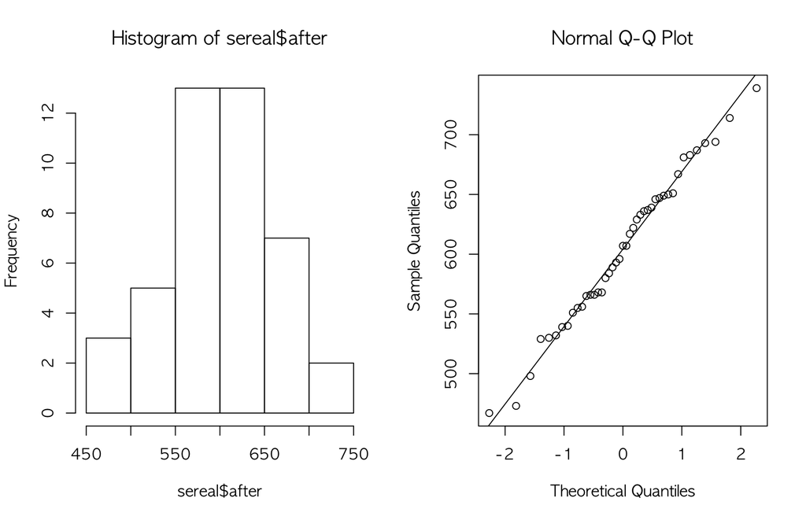

```r
par(mfrow = c(1,2))
hist(sereal$after)  # 종모양에 근사
qqnorm(sereal$after)
qqline(sereal$after)
```

### 1.3.3 등분산 F 검정

```r
var.test(sereal$before, sereal$after)
```

```
##
##  F test to compare two variances
##
## data:  sereal$before and sereal$after
## F = 2.9163, num df = 42, denom df = 42, p-value = 0.0007495
## alternative hypothesis: true ratio of variances is not equal to 1
## 95 percent confidence interval:
##  1.579626 5.384237
## sample estimates:
## ratio of variances
##           2.916347
```

```r
t.test(sereal$before, sereal$after,  alternative = "greater", paired = FALSE, var.equal = FALSE)  # 짝진표본, 이분산, 단측검정)
```

```
##
##  Welch Two Sample t-test
##
## data:  sereal$before and sereal$after
## t = 1.7925, df = 67.773, p-value = 0.03876
## alternative hypothesis: true difference in means is greater than 0
## 95 percent confidence interval:
##  2.413719      Inf
## sample estimates:
## mean of x mean of y
##  638.6744  604.0233
```

### 1.3.4 생각해 볼 문제

- 이와 같은 결과로부터 아침식사로 고섬유질 시리얼을 먹으면 점심식사에서 더 적은 칼로리를 섭취하게 된다고 인과관계로 설명할 수 있을까? 다른요인의 존재?
- 이 실험결과를 짝진표본이 아닌, 각기 다른 그룹에 대한 독립표본으로 실험한다면 결과는 어떻게 될까?

# 2 모비율에 대한 검정

- prop.test() 는 모비율에 대한 검정을 수행한다.
- prop.test() 함수는 여러 그룹의 비율(성공확률)이 같은지 또는 비율들이 특정한 값을 가지는지에 대해 카이제곱 검정을 수행한다.

## 2.1 One sample proportions test (Binomial test)

- 일표본 모비율에 대한 검정
- 이항 검정은 이항 분포를 이용하여 Bernoulli 분포 모수 θ 에 대한 가설을 조사하는 검정 방법이다. binom.test() 동일한 결과

### 2.1.1 [예제 4] 출구여론조사

출구여론조사는 임의표본에 속하는 투표소를 방금 나온 유권자들에게 어느 후보에게 지지하는 투표를 했는지를 물어보면서 이루어진다. 출구조사결과로부터 특정 후보를 지지하는 투표를 한 유권자들의 표본비율이 계산된다. 선두후보가 승리하기에 충분한 투표수를 확보할 것이라고 추론하기에 충분한 증가가 존재하는지를 결정하기 위해 통계기법이 사용된다.  
2000년 대통령 선거일 동안 플로리다 주에서 실시된 출구여론조사에서 유력후보인 민주당 Albert Gore(code=1) 후보와 공화당 George W. Bush(code=2) 에 대한 투표수를 기록하였다. 텔레비전 방송국들은 출구여론조사 데이터로부터 공화당 후보가 플로리다 주에서 승리할 것이라고 발표해야 하는가?

```r
elec <- read.csv("data/prop_elec.csv")
str(elec)
```

```
## 'data.frame':    765 obs. of  4 variables:
##  $ Votes    : int  2 1 1 2 2 1 1 1 1 2 ...
##  $ Gender   : int  1 1 1 1 1 1 1 1 1 1 ...
##  $ Education: int  1 1 1 1 1 1 1 3 1 1 ...
##  $ Income   : int  1 1 1 1 1 1 1 4 1 1 ...
```

```r
table(elec$Votes)  # 도수분포 계산
```

```
##
##   1   2
## 358 407
```

```r
prop.table(table(elec$Votes))  # 상대도수 계산
```

```
##
##         1         2
## 0.4679739 0.5320261
```

```r
# barplot(table(elec$Votes))  # 데이터 분포의 시각화
prop.test(sum(elec$Votes == "2"), length(elec$Votes == "2"), p = 0.5, alternative = "greater", conf.level = 0.95)
```

```
##
##  1-sample proportions test with continuity correction
##
## data:  sum(elec$Votes == "2") out of length(elec$Votes == "2"), null probability 0.5
## X-squared = 3.0118, df = 1, p-value = 0.04133
## alternative hypothesis: true p is greater than 0.5
## 95 percent confidence interval:
##  0.5016378 1.0000000
## sample estimates:
##         p
## 0.5320261
```

- 이 문제의 목적은 이 주의 투표 모집단의 특성을 파악하는 것. 데이터는 범주 데이터. 따라서 검정되어야 하는 모수는 이 주 전체에서 공화당 후보를 지지한 투표의 비율.
- 대립가설과 귀무가설은 각각 다음과 같고, 5%의 유의수준을 요구한다.

$H_1: p > 0.5$ $H_0: p = 0.5$

- p-value 0.04133 은 유의수준 5%보다 작기 때문에 귀무가설은 기각되고 플뢸다 주에서 George W. Bush 공화당 후보가 대통령 선거에서 승리했다고 추론하기에 충분한 증거가 존재한다고 결론내린다.

## 2.2 카이제곱 적합도검정 (Chi-square goodness of fit, Mutinomial test)

- 이항실험(binomial experiment) 의 일반형태인 다항실험(multinomial experience)에 의해 생성되는 데이터에 적용되는 적합도 검정(goodness of fit test)은 카이제곱검정이라고도 부른다.
- 한 시행에서 두개 이상의 가능한 결과들이 존재. 카테고리 분포의 모수 θ=(θ1,…,θK) 에 대한 가설을 조사하는 검정 방법.
- chisq.test() 함수 사용, 디폴트 귀무가설은 θ=(1/K,…,1/K).

### 2.2.1 [예제 5] 시장점유율 대한 검정

**회사A는 섬유유연제(fabric softner) 시장에서 자신의 시장점유율을 유지할 뿐만 아니라 가능한한 시장점유율을 증가시키기 위해 최근에 공격적인 마케팅 활동을 전개 하였다. 공격적인 마케팅 활동을 전개 하기 전에 회사A 의 시장점유율은 45% 이고 회사 B의 시장점유율은 40% 이었다. 다른 경쟁회사들은 나머지 15% 의 점유율을 시장점유율을 가지고 있었다. 이와 같은 시장점유율이 공격적인 마케팅 활동 후에 변화하였는지를 평가하기 위해 한 마케팅 분석가는 200명의 섬유유연제 고객으로 구성된 임의표본을 대상으로 선호조사를 하였다. 200명의 고객 중에서 102명은 회사 A 의 제품을 선호하였고 82명은 회사 B의 제품을 선호하였으며 나머지 16명은 경쟁회사들 중 한 회사의 제품을 선호하였다. 이 마케팅 분석가는 고객의 선호가 공격적인 광고활동 후에 변화했다고 5%의 유의수준에서 추론할 수 있는가?**

- 문제의 모집단 : 섬유유연제 고객들의 브랜드 선호
- 데이터 : 범주데이터_
- 시장점유율이 변화하였는지를 알기 원하기 때문에 마케팅활동 이전의 시장점유율이 귀무가설로 정의됨 $H_0 : p_1 = 0.45, p_2 = 0.40, p3 = 0.15$
- 대립가설은 시장점유율들이 변화했는가?에 대한 대답과 관련이 있으므로 다음과 같이 설정된다. $H_1 : 적어도 하나의 p_i 가 과거의 값과 동일하지 않다$

```r
obs <- c(102, 82, 16)
exp <- c(0.45, 0.40, 0.15)
chisq.test(x = obs, p = exp)
```

```
##
##  Chi-squared test for given probabilities
##
## data:  obs
## X-squared = 8.1833, df = 2, p-value = 0.01671
```

- 검정통계량 X-squared = 8.1833, p-value = 0.01671 이므로 귀무가설을 기각. 5% 유의수준에서 공격적인 마케팅 활동이 실행된 이후에 시장점유율이 변화하였다고 추론하기에 충분한 증거가 존재한다.

## 2.3 분할표 카이제곱 검정

- 분할표 카이제곱 검정(chi-squared test of a contingency table)은 두 범주형 변수가 관련되어 있고 두 개 이상 범주형 변수 모집단 간에 차이가 존재한다고 추론할 만큼 충분한 증거가 있는지를 결정하기 위해 사용된다.
- 두 범주형 변수 간의 관계를 그래프로 그리는 첫 단계로 분할표(contingency table) 또는 교차분류표(cross-classification table)가 사용된다.
  - 분할표 : 도수분포표를 2차원으로 확장한 형태. xtabs() 함수로 생성

### 2.3.1 [예제 6] 직업과 구독신문 간의 관계

**북미의 한 도시에는 4개의 경쟁 신문, 즉 *Globe and Mail(G&M), Post, Star, Sun* 등이 있다. 마케팅 활동을 설계하기 위해 신문의 광고관리자는 신문시장 중 어느 분할시장이 자신의 신문을 구독하는지를 알아야 한다. 구독신문과 직업 간의 관계를 분석하기 위해 한 서베이가 수행되었다. 표본에 포함된 신문구독자들에게 어느 신문을 구독하는지 (*Globe and Mail (1), Post (2), Star (3), Sun (4)*) 를 보고하고, 직업이 무엇인지 (블루칼라 근로자 (1), 화이트칼라 근로자 (2), 전문직 종사자 (3))를 답변하도록 요청하였다. 직업과 구독신문 간의 관계가 존재한다고 추론할 수 있는가?**

- 귀무가설은 두 변수 간에 관계가 없다고 설정된다. $H_0 : 두 변수는 독립이다$
- 대립가설은 한 변수가 다른 변수에 영향을 준다고 규정하고 다음과 같이 표현된다. $H_1 : 두 변수는 종속이다$

### 2.3.2 두 범주형 변수 간의 관계를 나타내기 위한 그래프

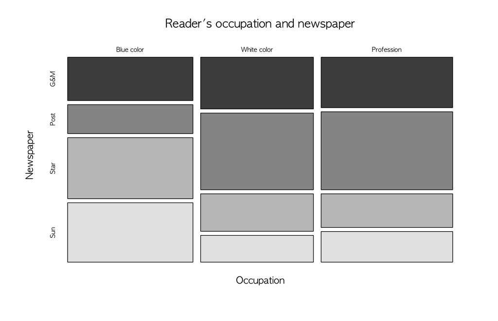

```r
news_reader <- read.csv("data/news_reader.csv")
# 요인명 변경
library(plyr)
news_reader$Newspaper <- revalue(factor(news_reader$Newspaper), c("1"="G&M", "2"="Post", "3"="Star", "4"="Sun"))
news_reader$Occupation <- revalue(factor(news_reader$Occupation), c("1"="Blue color", "2"="White color", "3"="Profession"))

xt <- xtabs(~ Occupation + Newspaper, data = news_reader)  # 분할표 생성
mosaicplot(xt, main = "Reader's occupation and newspaper", color = TRUE) # 모자이크플롯
```

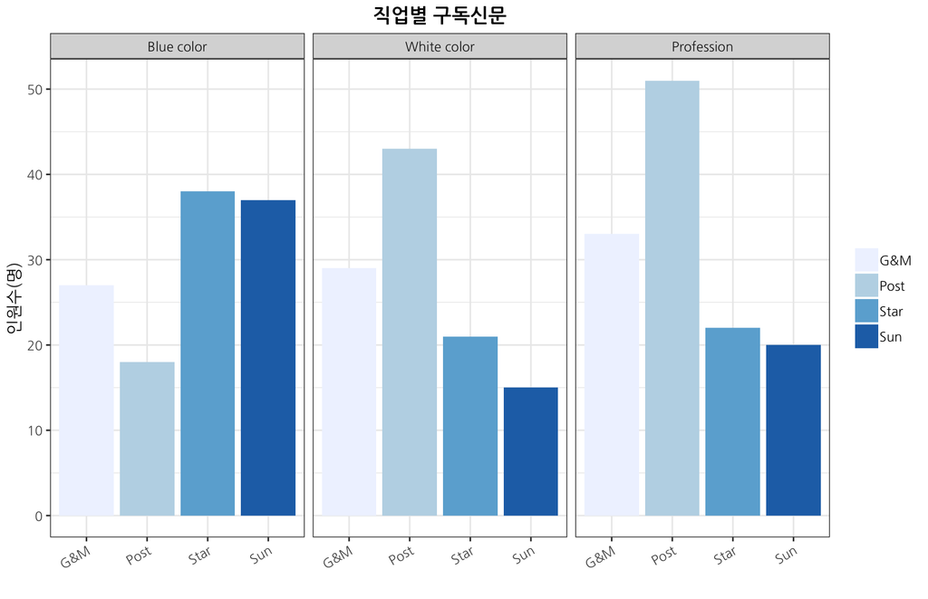

```r
# facet Graph
library(ggplot2)
ggplot(news_reader, aes(x = Newspaper, fill = factor(Newspaper))) +
    geom_bar(position = "dodge") +
    facet_grid(. ~ Occupation) +
    labs(x="", y="인원수(명)", title="직업별 구독신문") +
    theme_bw(base_size = 11, base_family = "NanumGothic") +
    scale_fill_brewer() +
    theme(
        plot.title = element_text(hjust = 0.5, face="bold"),
        axis.text.x = element_text(angle = 30, hjust = 1, vjust = 1),
        legend.title = element_blank(),
        legend.background = element_blank())
```

```r
chisq.test(xt)
```

```
##
##  Pearson's Chi-squared test
##
## data:  xt
## X-squared = 32.573, df = 6, p-value = 1.267e-05
```

- p-value = 1.267e-05 이므로 귀무가설을 기각하고 대립가설을 채택. 직업과 구독신문간의 관계가 존재한다는 유의한 증거가 존재함.

# 3 분산분석

- 분산분석(Analysis of Variance, ANOVA) 은 세개 이상의 모평균 간에 차이가 있는지를 결정하는 검정기법. 모평균들이 차이가 있다고 추론할 수 있는지를 결정하기 위해 데이터의 분산을 해석함.
- 분산분석은 분산의 추가적인 특징을 분석할 수 있다는 이점이 있으며 이를 통해서 분산을 처리효과(실제차이)와 오차(표본오차)로 구분할 수 있다.
  - 처리간 변동 (SST): 그룹간 평균의 차이에 기인
  - 처리내 변동(오차변동, SSE) : 각 그룹의 점수간 차이에 기반
- 관심인자의 수가 1개인 경우를 일원배치 분산분석(one-way ANOVA), 2개인 경우를 이원배치 분산분석(two-way ANOVA)이라 함
- 일원배치의 경우, 하나의 인자가 유의(significant) 하다는 말은 인자의 수준(levels, 이를 처리treatment라고도 함)에 따라 모평균이 모두 같지 않다는 의미이다.

## 3.1 One-way ANOVA

### 3.1.1 [예제 7] 연령대별 주식소유 비중

**인터넷 트레이딩이 매우 일반화되면서 온라인 트레이딩 비용도 매우 저렴해졌다. 이제 과거보다 주식시장에 투자하는 것이 더 쉽고 더 적은 비용이 든다. 이와 같은 변화의 효과는 무엇인가? 이러한 질문에 대답하게 위해 한 금융애널리스트는 임의로 366개 미국 가계를 표본추출하여 각 가계의 가장의 연령과 총금융자산 중 주식에 대한 비중을 보고하도록 요청하였다. 가장의 연령범주는 다음과 같이 분류되어 있다.**

- 젊은층 (35세 미만)
- 중년층 전반기 (35세 이상 ~ 49세 이하)
- 중년층 후반기 (50세 이상 ~ 65세 이하)
- 노년층 (65세 초과)

금융애널리스트는 특히 주식소유비중이 가장의 연령에 따라 변화하는지를 알아보는데 관심을 가지고 있었다. 이 데이터에 기초하여 금융애널리스트는 4개의 연령그룹간에 주식소유비중의 차이가 존재한다고 결정할 수 있는가?

- 데이터가 구간데이터(총금융자산 중 주식에 투자한 비중)이고 문제의 목표는 4개 모집단(연령범주)을 비교하는 것이다. 분석대상 모수들은 4개의 모형균, 즉 $\mu_1, \mu_2, \mu_3, \mu_4$ 이다.
- 귀무가설은 모평균들 간에 차이가 없다는 것을 나타내기 위해 다음과 같이 설정된다. $H_0 : \mu_1 = \mu_2 = \mu_3 = \mu_4$
- 분산분석은 귀무가설이 옳지 않다는 것을 보이기에 충분한 통계적 근거가 존재하는지를 결정한다. 따라서 대립가설은 항상 다음과 같이 설정된다. $H_1 : 적어도 두 모형균이 다르다$

```r
stock_rate <- read.csv("data/stock_rate.csv")
stock_rate <- stock_rate[, c(1:4)]
```

reshape::melt() 함수로 wide -> long 형태로 변형

```r
library(reshape2)
length(stock_rate$Early.Middle.Age)
```

```
## [1] 136
```

```r
id <- c(1:136)
stock_rate_n <- cbind(id, stock_rate)

stock_rate_lo <- melt(stock_rate_n, id = "id")
str(stock_rate_lo)
```

```
## 'data.frame':    544 obs. of  3 variables:
##  $ id      : int  1 2 3 4 5 6 7 8 9 10 ...
##  $ variable: Factor w/ 4 levels "Young","Early.Middle.Age",..: 1 1 1 1 1 1 1 1 1 1 ...
##  $ value   : num  24.8 35.5 68.7 42.2 49.5 64.6 58.3 72 25.6 39.8 ...
```

```r
summary(aov(value ~ variable, data = stock_rate_lo))
```

```
##              Df Sum Sq Mean Sq F value Pr(>F)
## variable      3   3746  1248.7   2.792 0.0403 *
## Residuals   362 161892   447.2
## ---
## Signif. codes:  0 '***' 0.001 '**' 0.01 '*' 0.05 '.' 0.1 ' ' 1
## 178 observations deleted due to missingness
```

```r
anova(lm(value ~ variable, data = stock_rate_lo))
```

```
## Analysis of Variance Table
##
## Response: value
##            Df Sum Sq Mean Sq F value  Pr(>F)
## variable    3   3746 1248.68  2.7921 0.04034 *
## Residuals 362 161892  447.22
## ---
## Signif. codes:  0 '***' 0.001 '**' 0.01 '*' 0.05 '.' 0.1 ' ' 1
```

- 검정통계량 값은 F = 2.79 이고, 검정의 p 값은 0.0403 이다.
  - 결과 중 variables 행이 처리간 변동, Residuals 행이 처리내 변동
- 이것은 총금융자산 중 주식에 투자하는 평균비중은 적어도 두 연령그룹간에 다르다고 추론할 수 있는 증거가 존재한다는 것을 의미.

### 3.1.2 분산분석의 진단

분산분석 결과가 의미가 있으려면 다음의 가정이 충족되어야 한다.

1. 잔차의 분포가 독립이다.
2. 잔차의 분산이 동일하다
3. 잔차의 분포가 $N(0,\sigma^2)$ 이다.

### 3.1.3 Plot Diagnostics for an lm Object

진단플롯은 plot(lm()) 함수로 얻을 수 있다.

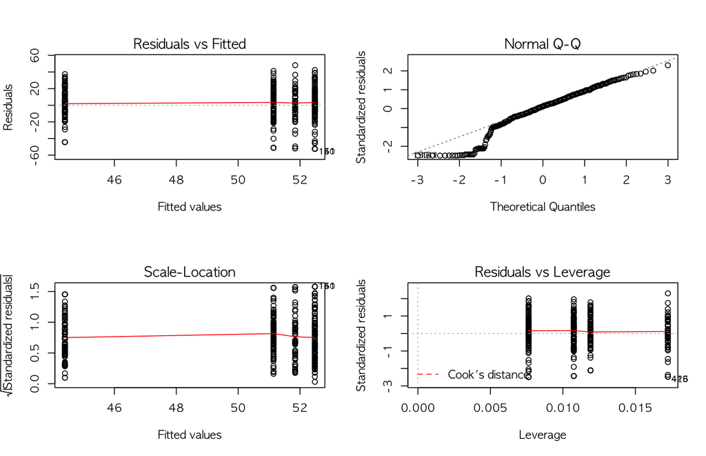

```r
par(mfrow = c(2,2))
plot(lm(value ~ variable, data = stock_rate_lo))
```

- **Residuals vs. Fitted** : 잔차의 분포가 예측값과 독립적인지 확인하는데 사용됨. 어떠한 특별한 패턴도 보이지 않으면 선형모형이 적절하다고 할 수 있다.
- **Normal Q-Q** : 표준화된 잔차의 분포가 정규분포가 가까운지를 확인함. 점들이 기울기가 1인 직선을 잘 따르면 정규성 가정에 문제가 없다고 할 수 있다.
  - 표준화된 잔차 (standardized residuals) : 평균을 빼고 표준편차로 나누어서 잔차를 표준화. 평균은 0으로 오고 분산을 1로.
- **Scale-Location** : 잔차의 절댓값의 제곱근 sqrt(|residuals|) 과 예측값 사이의 관계를 보여줌. y축의 제곱합(표준화 잔차)이 일정하면 등분산 가정을 잘 따른다고 할 수 있다.
- **Residuals vs. leverages** : 표준화된 잔차와 지렛값(leverage: 평균값에서 떨어진 정도. 평균에 몰려있을수록 좋은 것) 간의 관계를 보여준다. 라벨(cook’s distance 값이 1이상이어서 제거하고 돌리는게 안전한 행번호)이 붙은 점은 회귀선에 심하게 영향을 끼치는 영향점으로 면밀한 조사가 필요하다.

## 3.2 Two-way ANOVA

### 3.2.1 [예제 8] 성별과 사회경제적 수준이 성적이 미치는 영향

**hsb2 (High School And Beyond Survey) dataset은미국 국립 교육 통계 센터(NCES)에서 시행하는 고등학교 고학년생에 대한 서베이 “High School and Beyond survey” 에서 무작위로 추출된 200개의 샘플 관측치 데이터로 아래와 같은 11개 변수로 구성되어 있다. 성별과 사회경제적 수준이 읽기성적에 영향을 미친다고 추론할 수 있는가?**

| 변수 | 변수설명 |
| --- | --- |
| id | Student ID |
| gender | Student’s gender (0=male 1=female) |
| race | Student’s race (1=hispanic 2=asian 3=african-amer 4=white) |
| ses | Socio economic status of student’s family (low=1 middle=2 high=3) |
| schtyp | Type of school (1=public 2=private) |
| prog | Type of program (1=general 2=academic 3=vocational) |
| read | Standardized reading score |
| write | Standardized writing score |
| math | Standardized math score |
| science | Standardized science score |
| socst | Standardized social studies score |

```r
# within()을 이용하여 원데이터를 가공. within(data, exp)
hsb2 <- within(read.csv("data/hsb2.csv", fileEncoding = "UTF-8"), {
    gender <- factor(gender)
    race <- factor(race)
    ses <- factor(ses)
    schtyp <- factor(schtyp)
    prog <- factor(prog)
})

str(hsb2)
```

```
## 'data.frame':    200 obs. of  11 variables:
##  $ id     : int  70 121 86 141 172 113 50 11 84 48 ...
##  $ gender : Factor w/ 2 levels "0","1": 1 2 1 1 1 1 1 1 1 1 ...
##  $ race   : Factor w/ 4 levels "1","2","3","4": 4 4 4 4 4 4 3 1 4 3 ...
##  $ ses    : Factor w/ 3 levels "1","2","3": 1 2 3 3 2 2 2 2 2 2 ...
##  $ schtyp : Factor w/ 2 levels "1","2": 1 1 1 1 1 1 1 1 1 1 ...
##  $ prog   : Factor w/ 3 levels "1","2","3": 1 3 1 3 2 2 1 2 1 2 ...
##  $ read   : int  57 68 44 63 47 44 50 34 63 57 ...
##  $ write  : int  52 59 33 44 52 52 59 46 57 55 ...
##  $ math   : int  41 53 54 47 57 51 42 45 54 52 ...
##  $ science: int  47 63 58 53 53 63 53 39 58 50 ...
##  $ socst  : int  57 61 31 56 61 61 61 36 51 51 ...
```

- 귀무가설은 모평균들 간에 차이가 없다는 것을 나타내기 위해 다음과 같이 설정된다. $H_0 : \mu_1 = \mu_2 = \mu_3 = \mu_4 = \mu_5 = \mu_6$
- 분산분석은 귀무가설이 옳지 않다는 것을 보이기에 충분한 통계적 근거가 존재하는지를 결정한다. 따라서 대립가설은 항상 다음과 같이 설정된다. $H_1 : 적어도 두 모평균이 다르다$
- 반복이 없는 경우 : aov(y ~ A + B, data = )
- 반복이 있는 경우 : aov(y ~ A * B, data = )

```r
# str(hsb2)
summary(aov(read ~ gender * ses, data = hsb2))  # 상호작용 여부
```

```
##              Df Sum Sq Mean Sq F value   Pr(>F)
## gender        1     59    58.9   0.602 0.438701
## ses           2   1782   890.9   9.100 0.000167 ***
## gender:ses    2     87    43.4   0.444 0.642424
## Residuals   194  18992    97.9
## ---
## Signif. codes:  0 '***' 0.001 '**' 0.01 '*' 0.05 '.' 0.1 ' ' 1
```

```r
summary(aov(read ~ race * ses, data = hsb2))
```

```
##              Df Sum Sq Mean Sq F value   Pr(>F)
## race          3   1750   583.3   6.253 0.000455 ***
## ses           2   1157   578.4   6.201 0.002466 **
## race:ses      6    476    79.3   0.850 0.532553
## Residuals   188  17537    93.3
## ---
## Signif. codes:  0 '***' 0.001 '**' 0.01 '*' 0.05 '.' 0.1 ' ' 1
```

# 4 상관분석

## 4.1 상관계수

- 상관계수는 두 변수 간의 선형적인 관계를 나타내는 측도
- 상관계수는 -1과 1사이의 값을 가지며, 1 또는 -1에 가까울수록 선형적인 관계가 강하며, 0에 가까울수록 그 관계가 약하다고 할 수 있다.
- 피어슨 상관계수(모수적), 스피어만 상관계수, 켄달의 타우(비모수적)
- cor() 함수로 상관분석을 수행한다.

```r
cor(hsb2$read, hsb2$write)
```

```
## [1] 0.5967765
```

## 4.2 상관계수에 대한 검정

- 모상관계수(population coefficient of correlation) 는 그리스어 $\rho$ 로 표현된다. 거의 언제나 알려져 있지 않은 모수이기 때문에 표본데이터로부터 추정되어야 한다.
- 두 변수 간에 선형관계가 존재하지 않을 때 $\rho = 0$ 이다. 이를 위해 다음과 같은 가설들을 검정한다.

$H_0 : \rho = 0$ $H_1 : \rho != 0$

```r
cor.test(hsb2$read, hsb2$write)
```

```
##
##  Pearson's product-moment correlation
##
## data:  hsb2$read and hsb2$write
## t = 10.465, df = 198, p-value < 2.2e-16
## alternative hypothesis: true correlation is not equal to 0
## 95 percent confidence interval:
##  0.4993831 0.6792753
## sample estimates:
##       cor
## 0.5967765
```

## 4.3 상관분석 시각화

- 상관행렬의 시각화를 위해 psych 패키지의 pairs.panel() 함수와 cor.plot() 이용
- pairs.panel() 함수는 산점도와 함께 모든 변수들 간의 상관관계를 보여준다. 변수의 수가 6~10개 일때 효과적이다.

```r
library(psych)
```

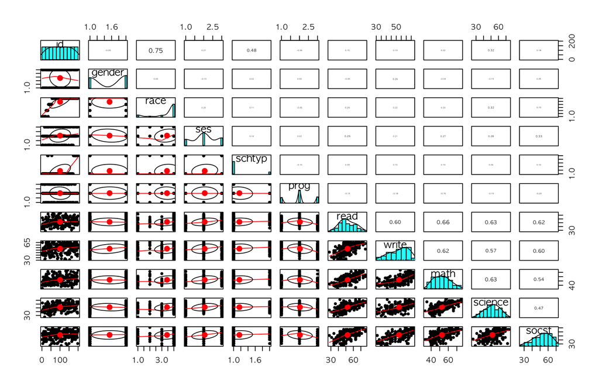

```r
pairs.panels(hsb2, scale = T)
```

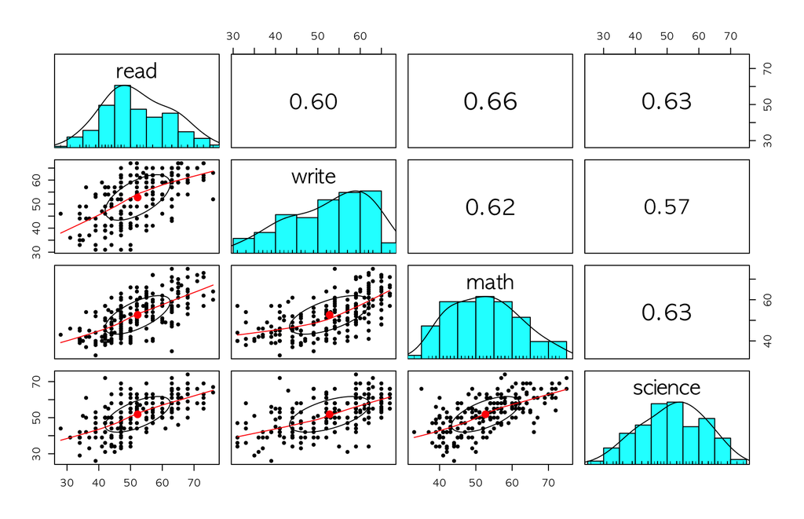

```r
pairs.panels(hsb2[, c(7:10)], scale = T)
```

corrplot() 은 변수의 수가 많을 경우에 유용한 방법으로, 상관 또는 요인행렬에 대해 이미지 플롯을 제공한다.

```r
car_cor <- cor(mtcars)
round(car_cor, 2)
```

```
##        mpg   cyl  disp    hp  drat    wt  qsec    vs    am  gear  carb
## mpg   1.00 -0.85 -0.85 -0.78  0.68 -0.87  0.42  0.66  0.60  0.48 -0.55
## cyl  -0.85  1.00  0.90  0.83 -0.70  0.78 -0.59 -0.81 -0.52 -0.49  0.53
## disp -0.85  0.90  1.00  0.79 -0.71  0.89 -0.43 -0.71 -0.59 -0.56  0.39
## hp   -0.78  0.83  0.79  1.00 -0.45  0.66 -0.71 -0.72 -0.24 -0.13  0.75
## drat  0.68 -0.70 -0.71 -0.45  1.00 -0.71  0.09  0.44  0.71  0.70 -0.09
## wt   -0.87  0.78  0.89  0.66 -0.71  1.00 -0.17 -0.55 -0.69 -0.58  0.43
## qsec  0.42 -0.59 -0.43 -0.71  0.09 -0.17  1.00  0.74 -0.23 -0.21 -0.66
## vs    0.66 -0.81 -0.71 -0.72  0.44 -0.55  0.74  1.00  0.17  0.21 -0.57
## am    0.60 -0.52 -0.59 -0.24  0.71 -0.69 -0.23  0.17  1.00  0.79  0.06
## gear  0.48 -0.49 -0.56 -0.13  0.70 -0.58 -0.21  0.21  0.79  1.00  0.27
## carb -0.55  0.53  0.39  0.75 -0.09  0.43 -0.66 -0.57  0.06  0.27  1.00
```

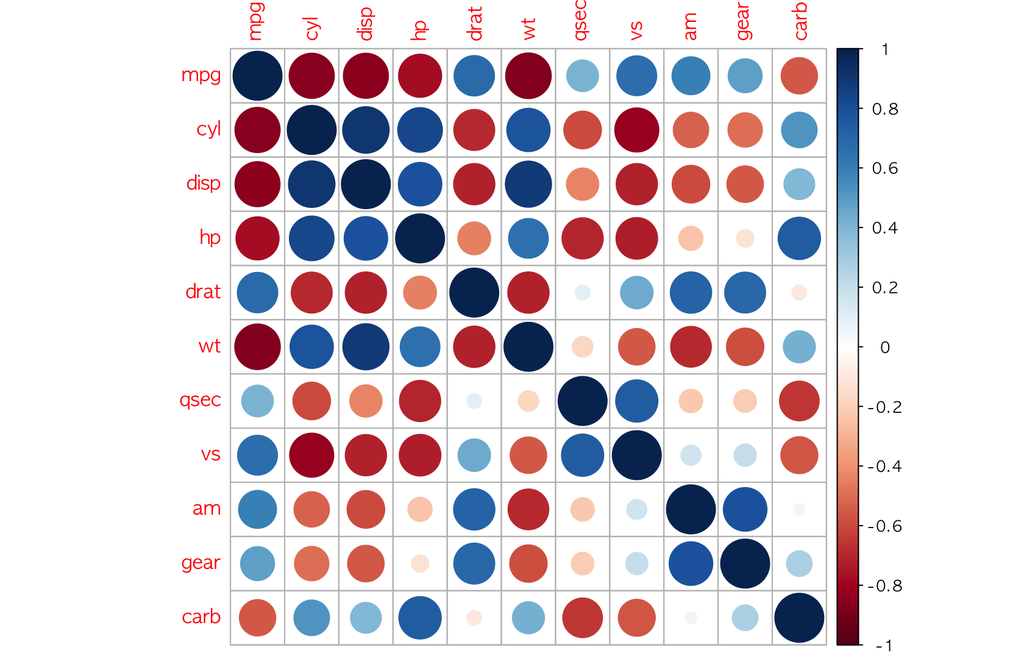

```r
library(corrplot)
corrplot(car_cor)
```

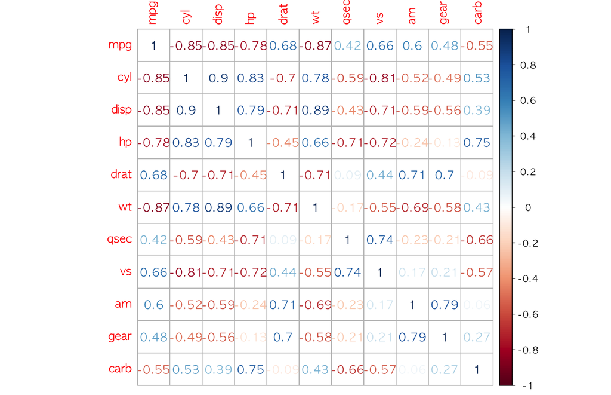

```r
corrplot(car_cor, method = "number")
```

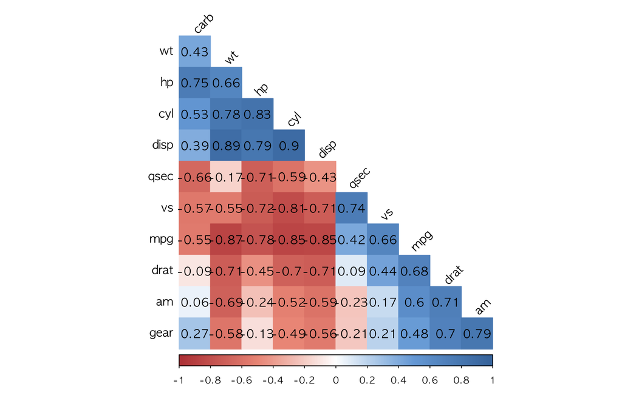

```r
col <- colorRampPalette(c("#BB4444", "#EE9988", "#FFFFFF", "#77AADD", "#4477AA"))
corrplot(car_cor,
         method = "color", # 색깔로 표현
         col = col(200), # 색상 200개 선정
         type = "lower", # 왼쪽 아래 행렬만 표시
         order = "hclust", # 유사한 상관계수끼리 군집화
         addCoef.col = "black", # 상관계수 색깔
         tl.col = "black", # 변수명 색깔
         tl.srt = 45, # 변수명 45도 기울임
         diag = F) # 대각행렬 제외
```

# 5 선형회귀분석

회귀분석(Regression Analysis)은 데이터로부터 독립변수(또는 예측변수)의 함수를 추정하여 종속변수(또는 반응변수)를 예측하는 방법

$Y = \beta_0 + \beta_1x_1 + \beta_2x_2 + ... +\beta_kx_k + \epsilon$

- $Y$ : 종속변수
- $x_1, x_2, ... x_k$ : 독립변수들
- $\beta_0, \beta_1, ... \beta_k$ : 회귀계수 ($\beta_0$ : 절편(intercept) , $\beta_1, \beta_2, ... , \beta_k$ : 경사(slope))
- $\epsilon$ : 오차변수

regression 이라는 용어는 자녀의 키와 부모의 키 간의 관계를 분석하면서 Sir Franscis Galton 에 의해 1885년에 처음으로 사용되었다. 그는 “한 남성의 각 특성은 그의 혈족 남성과 공유하지만 평균적으로 더 적은 정도 공유한다”는 “일반적 회귀의 법칙”(law of universal regression)을 공식화하였다.

## 5.1 단순선형회귀분석 (simple linear regression)

단순선형회귀는 독립변수와 종속변수가 모두 1개인 직선모형

$y = \beta_0 + \beta_1x + \epsilon$

- $y$ : 종속변수
- $x$ : 독립변수
- $\beta_0$ : $y$ 절편
- $\beta_1$ : 직선의 기울기
- $\epsilon$ : 오차변수

lm() 과 summary(lm()) 함수는 선형모형을 최소제곱법(잔차의 제곱합을 최소화) 으로 추정함.

### 5.1.1 [예제 9] 중고차 가격과 주행거리 간의 관계

북미 전체의 자동차 딜러들은 고객기 새 자동차를 구매할 때 가져오는 중고차의 가격을 결정하는데 도움을 얻기 위해 “blue book” 을 사용한다. 월간으로 출판되는 Blue Book 에는 기본 자동차 모델들의 중고차 가격이 정리되어 있다. Blue Book 은 중고차 상태와 선택사항 특성에 따라 각 자동차 모델의 다양한 가격들을 제시한다. 중고차의 가격은 많은 중고차 딜러들의 중고차 공급원인 최근 중고차 경매에서 지불된 평균가격에 기초하여 결정된다. 그러나 중고차 구매자에게 하나의 중요한 요소가 중고차의 주행요소라는 사실에도 불구하고 Blue Book 은 주행거리에 의해 결정되는 가치를 제시하지 않는다.  
이 문제를 조사하기 위해, 한 중고차 딜러는 임의로 지난 달 동안 중고차 경매에서 판대된 100대의 3년된 Toyota Camry 를 선택하였다. 각 자동차는 최상의 상태였고, 자동 변속기, AM/FM, 카테트테이프 플레이어, 에어컨을 장착하고 있었다. 이 딜러는 중고차의 가격(1,000달러 기준) 과 주행거리(1,000마일 기준)을 기록하였다. 이와같은 데이터이 일부가 다음과 같이 정리되어 있다. 이 딜러는 중고차 가격과 주행거리 간의 관계를 나타내는 회귀선을 구하기 원한다.

```r
# import file
toyota <- readxl::read_xlsx("data/toyota_used.xlsx")
str(toyota)
```

```
## Classes 'tbl_df', 'tbl' and 'data.frame':    100 obs. of  3 variables:
##  $ Price   : num  14.6 14.1 14 15.6 15.6 14.7 14.5 15.7 15.1 14.8 ...
##  $ Odometer: num  37.4 44.8 45.8 30.9 31.7 34 45.9 19.1 40.1 40.2 ...
##  $ Color   : num  1 1 3 3 2 2 1 3 1 1 ...
```

```r
# 회귀분석
toyota_lm <- lm(toyota$Price ~ toyota$Odometer)
summary(lm(toyota$Price ~ toyota$Odometer))
```

```
##
## Call:
## lm(formula = toyota$Price ~ toyota$Odometer)
##
## Residuals:
##      Min       1Q   Median       3Q      Max
## -0.68679 -0.27263  0.00521  0.23210  0.70071
##
## Coefficients:
##                  Estimate Std. Error t value Pr(>|t|)
## (Intercept)     17.248727   0.182093   94.72   <2e-16 ***
## toyota$Odometer -0.066861   0.004975  -13.44   <2e-16 ***
## ---
## Signif. codes:  0 '***' 0.001 '**' 0.01 '*' 0.05 '.' 0.1 ' ' 1
##
## Residual standard error: 0.3265 on 98 degrees of freedom
## Multiple R-squared:  0.6483, Adjusted R-squared:  0.6447
## F-statistic: 180.6 on 1 and 98 DF,  p-value: < 2.2e-16
```

- *p value* 가 충분히 작음 : 중고차 가격과 주행거리의 선형효과는 통계적으로 유의하다.
- 회귀선은 다음과 같이 추정된다. (추정치는 보통 hat, ^ ) $\hat{y}$ = 17.25 - 0.0669x
  - 기울기계수 -0.0669 는 추가적인 1,000 마일의 주행거리에 대하여 가격은 평균적으로 66.9 달러 감소한다는 것을 의미.
  - 기술적으로 말하면 y절편은 회귀선과 y축이 만나는 점이다. 이것은 x=0 일 때, 즉 자동차가 전혀 주행하지 않았을 때 판매가격은 17,250 달러라는 것을 의미하므로, 이 수치를 주행되지 않은 자동차의 판매가격이라고 해석할 수 있는가?
- 회귀계수의 해석은 100개 관측치로 구성되는 표본(19.1 ~ 49.2 범위)에 대해서만 적합함.

```r
range(toyota$Odometer)
```

```
## [1] 19.1 49.2
```

모집단에 대한 정보를 추론하기 위해서는 통계적 추론기법들이 필요함.

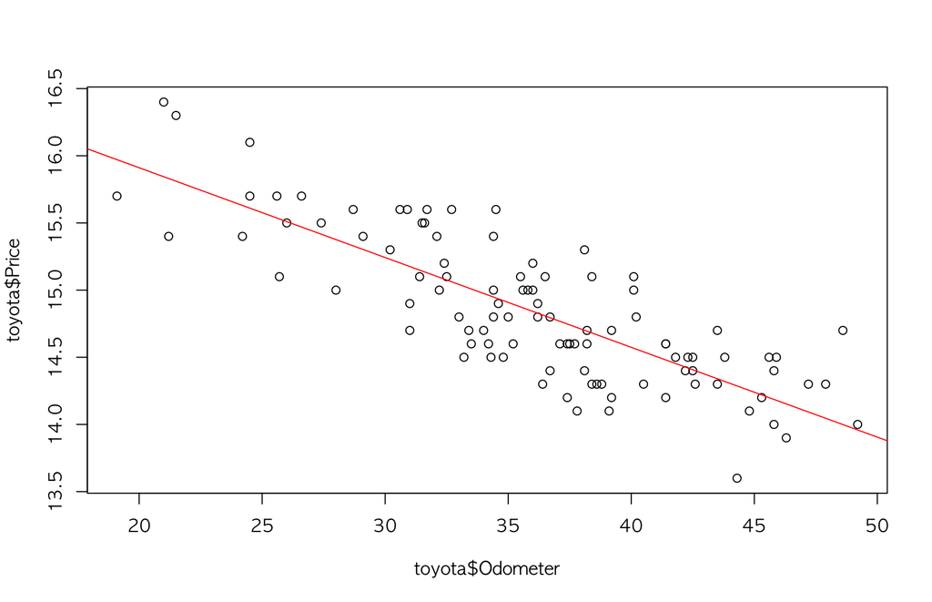

```r
# 산점도 상에 회귀선 그리기
plot(toyota$Price ~ toyota$Odometer)
abline(toyota_lm, col="red")
```

## 5.2 모형적합도(goodness of fit) 검정

summary(lm()) 의 마지막 두 줄은 각 모수 뿐 아니라 모형 전체의 설명력을 나타내므로, 모형의 적합도를 나타내는 통계량이라 볼 수 있음.

## 5.3 회귀분석 진단 (regression diagnostic)

회귀분석의 타당성을 위해서는 잔차는 일정한 분산을 가진 정규분포를 따라야 하고, 서로 독립이어야 한다. 즉 다음 조건이 충족되어야 한다.

1. 잔차의 분포가 정규분포이다.
2. 잔차의 분포가 동일하다 (등분산성)
3. 잔차의 분포가 독립이다.

### 5.3.1 (1) 정규분포

잔차의 히스토그램을 그려서 잔차가 정규분포를 따르는지 확인할 수 있음.

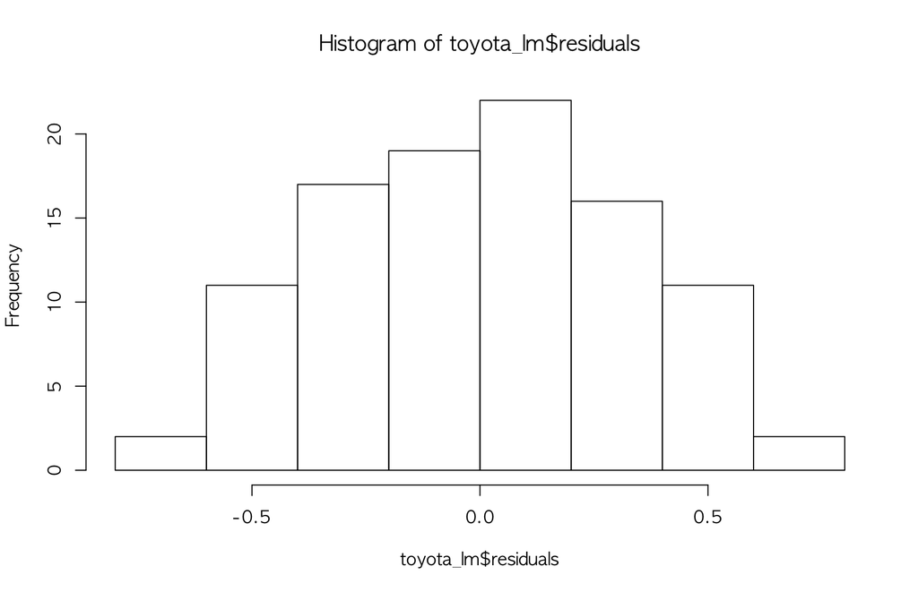

```r
hist(toyota_lm$residuals)
```

히스토그램은 종모양으로 그려져 있어서 잔차가 정규분포를 따른다고 확인할 수 있다.

### 5.3.2 (2) 등분산

- 분산 sigms^2 은 상수여야 함. 이와같은 필요조건이 충족되는 상태를 등분산(homoscedasticity) 라고 부른다. (필요조건이 위반되는 상태는 이분산 heteroscedasticity라 부름)
- y의 예측치에 대해 그려진 잔차 점들이 변화하거나, 일정한 패턴을 보여준다면 이분산

### 5.3.3 (3) 독립

- 잔차들 간에 어떠한 관계도 존재해서는 안된다. 잔차들 간에 어떤 관계가 존재하면 자기상관(autocorrelation)이 존재할 가능성이 있다.
- 특정한 패턴이 나타나면 잔차가 독립이어야 한다는 조건이 충족되지 않을 수 있다.

R에서는 lm 클래스 객체에 plot() 을 실행하면 이러한 선형모형진단 플롯을 그려준다.

```r
# Plot Diagnostics for an lm Object
class(toyota_lm)
```

```
## [1] "lm"
```

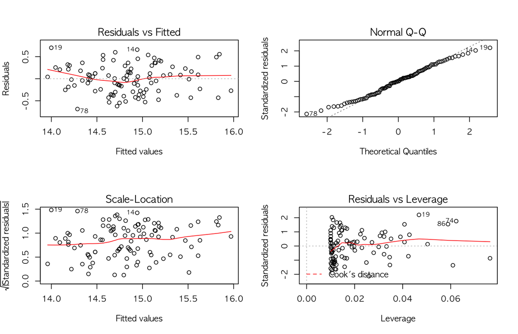

```r
par(mfrow = c(2,2))
plot(toyota_lm)
```

- Residuals vs. Fitted : 잔차의 분포가 예측값과 독립적인지 확인하는데 사용됨. 어떠한 특별한 패턴도 보이지 않으면 선형모형이 적절하다고 할 수 있다.
- Normal Q-Q : 표준화된 잔차의 분포가 정규분포가 가까운지를 확인함. 점들이 기울기가 1인 직선을 잘 따르면 정규성 가정에 문제가 없다고 할 수 있다.
  - 표준화된 잔차 (standardized residuals) : 평균을 빼고 표준편차로 나누어서 잔차를 표준화. 평균은 0으로 오고 분산을 1로.
- Scale-Location : 잔차의 절댓값의 제곱근 sqrt(|residuals|) 과 예측값 사이의 관계를 보여줌. y축의 제곱합(표준화 잔차)이 일정하면 등분산 가정을 잘 따른다고 할 수 있다.
- Residuals vs. leverages : 표준화된 잔차와 지렛값(leverage: 평균값에서 떨어진 정도. 평균에 몰려있을수록 좋은 것) 간의 관계를 보여준다. 라벨(cook’s distance 값이 1이상이어서 제거하고 돌리는게 안전한 행번호)이 붙은 점은 회귀선에 심하게 영향을 끼치는 영향점으로 면밀한 조사가 필요하다.

## 5.4 이상치와 영향치 확인

```r
# 영향점 19, 74, 86 행 확인
toyota[c(19, 74, 86), ]
```

```
## # A tibble: 3 x 3
##   Price Odometer Color
##   <dbl>    <dbl> <dbl>
## 1  14.7     48.6     1
## 2  16.4     21       2
## 3  16.3     21.5     2
```

```r
# 영향점 각각에 대한 모델의 예측값
toyota_lm$fitted.values[c(19, 74, 86)]
```

```
##       19       74       86
## 13.99929 15.84465 15.81122
```

```r
# 영향점 각각에 대한 모델의 잔차
toyota_lm$residuals[c(19, 74, 86)]
```

```
##        19        74        86
## 0.7007117 0.5553512 0.4887817
```

```r
#toyota[c(1, 2, 3), ]
#toyota_lm$fitted.values[c(1, 2, 3)]
#toyota_lm$residuals[c(1, 2, 3)]
```

## 5.5 회귀모형의 진단순서

실제 적용에서는 회귀모형의 진단이 먼저 이루어져야 함. 선형회귀모형의 평가와 회귀식을 활용한 예측과 추정보다 먼저 필요조건들이 충족되는지를 조사하여야 함.

회귀분석과정을 단계별로 정리하면 다음과 같다.

1. 관심대상이 되는 종속변수와 선형관계를 가지고 있는 것으로 여겨지는 독립변수를 찾는다.
2. 선형모형이 적합한지를 결정하기 위해 산포도를 그리고 가능한 이상치들을 판변한다.
3. 회귀식을 구한다.
4. 잔차를 계산하고 필요조건들을 확인한다.
   1. 잔차가 정규분포를 따르는가?
   2. 잔차의 분산이 일정한가?
   3. 잔차들은 독립적인가?
   4. 이상치와 영향치를 확인한다.
5. 선형회귀모형의 적합도를 평가한다.
   1. 추정치의 표준오차를 확인한다.
   2. 선형관계가 존재하는지 검정한다. (p-value)
   3. 결정계수를 확인한다.
6. 선형회귀모형이 데이터를 비교적 잘 설명하면, 종속변수의 값과 종속변수의 기대치를 예측하기 위해 회귀식을 사용한다.

RMD 파일에서 R code 추출

```r
library(knitr)
purl("1-2.statistical_test.R", encoding = "UTF-8")
```

```
##
  |.................................................................| 100%
```

```
## [1] "1-2.statistical_test.R"
```